# Report

Jeffrey Liang

12/3/2020

# Predicting Model For Tickets Around The Cafe

From previously data exploration and data analysis, we know that the tickets issue is different in borough, hour and weekdays.

Therefore, for us to predicting the possible amount of ticket around certain area of a cafe( in our case, 100m around the cafe), we use these variables as our interested predictors for our model.

```r
cafe =
  read_csv("data/map_data.csv") %>%
  select(business_name, adress:n_risk) %>%
  full_join(
    read_csv("data/map_data.csv") %>%
      distinct(business_name, weekday) %>%
      mutate(hour = list(1:24))
  ) %>%
  unnest(hour) %>%
  left_join(read_csv("data/map_data.csv")) %>%
  drop_na()%>%
  mutate(across(where(is.numeric), replace_na, replace = 0)) %>%
  ungroup() %>%
  left_join(read_csv(
    here::here("data/Sidewalk_Caf__Licenses_and_Applications_clean.csv")
  ) %>%
    select(business_name, borough, street_name)) %>%
  mutate(weekday =
           if_else(weekday %in% c("Saturday", "Sunday"),
                   "Weekend",
                   "Workday"))%>%
  select(business_name,borough:hour_day_risk)
```

Our interested dependent is **hour_day_risk**: the amount of tickets issue in this area of certain hour and weekday. We can interpret that this dependent is following poison distribution, so we need to consider regression model for this settings.

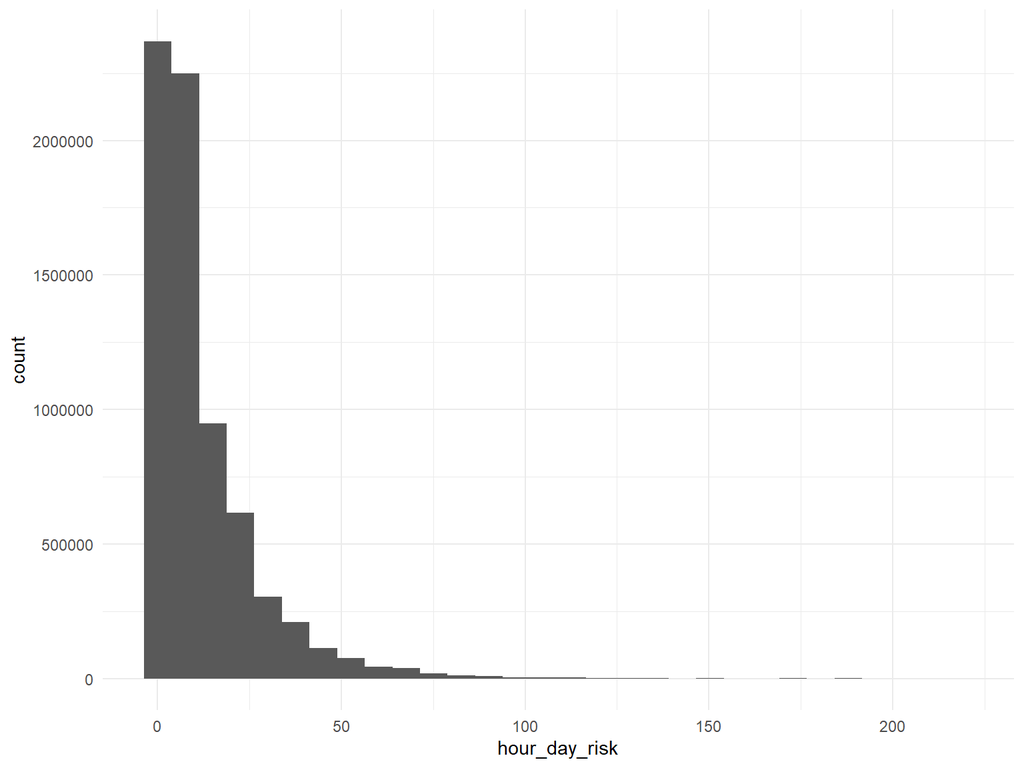

```r
cafe %>%
  ggplot(aes(x = hour_day_risk))+geom_histogram()
```

And here’s the predictors in our model:

- *hour* : integer reflecting the 24 hour format of hour of the day;
- *weekday* : factors reflecting either it is a workday or weekend;
- *borough* : factors reflecting which borough this area is in;
- *tickets* : float reflecting the baseline total issue tickets of the area;